# پروژه صفرم

```python
import numpy as np
import pandas as pd
import matplotlib.pyplot as plt
import scipy as sp
```

## پرسش 1:

```python
df = pd.read_csv('train.csv')
display(df)
```

|  | PassengerId | Survived | Pclass | Name | Sex | Age | SibSp | Parch | Ticket | Fare | Cabin | Embarked |
| --- | --- | --- | --- | --- | --- | --- | --- | --- | --- | --- | --- | --- |
| 0 | 1 | 0 | 3 | Braund, Mr. Owen Harris | male | 22.0 | 1 | 0 | A/5 21171 | 7.2500 | NaN | S |
| 1 | 2 | 1 | 1 | Cumings, Mrs. John Bradley (Florence Briggs Th... | female | 38.0 | 1 | 0 | PC 17599 | 71.2833 | C85 | C |
| 2 | 3 | 1 | 3 | Heikkinen, Miss. Laina | female | 26.0 | 0 | 0 | STON/O2. 3101282 | 7.9250 | NaN | S |
| 3 | 4 | 1 | 1 | Futrelle, Mrs. Jacques Heath (Lily May Peel) | female | 35.0 | 1 | 0 | 113803 | 53.1000 | C123 | S |
| 4 | 5 | 0 | 3 | Allen, Mr. William Henry | male | 35.0 | 0 | 0 | 373450 | 8.0500 | NaN | S |
| ... | ... | ... | ... | ... | ... | ... | ... | ... | ... | ... | ... | ... |
| 886 | 887 | 0 | 2 | Montvila, Rev. Juozas | male | 27.0 | 0 | 0 | 211536 | 13.0000 | NaN | S |
| 887 | 888 | 1 | 1 | Graham, Miss. Margaret Edith | female | 19.0 | 0 | 0 | 112053 | 30.0000 | B42 | S |
| 888 | 889 | 0 | 3 | Johnston, Miss. Catherine Helen "Carrie" | female | NaN | 1 | 2 | W./C. 6607 | 23.4500 | NaN | S |
| 889 | 890 | 1 | 1 | Behr, Mr. Karl Howell | male | 26.0 | 0 | 0 | 111369 | 30.0000 | C148 | C |
| 890 | 891 | 0 | 3 | Dooley, Mr. Patrick | male | 32.0 | 0 | 0 | 370376 | 7.7500 | NaN | Q |

891 rows × 12 columns

```python
df.describe()
```

|  | PassengerId | Survived | Pclass | Age | SibSp | Parch | Fare |
| --- | --- | --- | --- | --- | --- | --- | --- |
| count | 891.000000 | 891.000000 | 891.000000 | 714.000000 | 891.000000 | 891.000000 | 891.000000 |
| mean | 446.000000 | 0.383838 | 2.308642 | 29.699118 | 0.523008 | 0.381594 | 32.204208 |
| std | 257.353842 | 0.486592 | 0.836071 | 14.526497 | 1.102743 | 0.806057 | 49.693429 |
| min | 1.000000 | 0.000000 | 1.000000 | 0.420000 | 0.000000 | 0.000000 | 0.000000 |
| 25% | 223.500000 | 0.000000 | 2.000000 | 20.125000 | 0.000000 | 0.000000 | 7.910400 |
| 50% | 446.000000 | 0.000000 | 3.000000 | 28.000000 | 0.000000 | 0.000000 | 14.454200 |
| 75% | 668.500000 | 1.000000 | 3.000000 | 38.000000 | 1.000000 | 0.000000 | 31.000000 |
| max | 891.000000 | 1.000000 | 3.000000 | 80.000000 | 8.000000 | 6.000000 | 512.329200 |

این تابع به ازای هر ستون در dataframe اطلاعات زیر را محاسبه کرده و برمی‌گرداند (ستون‌های انتخاب شده را می‌توان با اسنفاده از پارامترهای ورودی تابع تغییر داد):

- تعداد سطرهای پر
- میانگین داده‌ها
- انحراف معیار داده‌ها
- کوچک‌‌ترین داده
- چارک اول
- چارک دوم
- چارک سوم
- بزرگترین داده

تابع مذکور به صورت پیش فرض فقط ستون‌هایی که داده آن‌ها از جنس عدد است را نمایش می‌دهد. برای نمایش همه ستون‌ها می‌توانیم پارامتر ورودی include را به 'all' تغییر دهیم.  
این تابع یک پارامتر ورودی به نام percentiles دارد که که یک لیست را دریافت می‌کند و داده‌ها را بر اساس این لیست دسته‌بندی کرده و خروجی آن را برمی‌گرداند. تمامی مقادیر این لیست باید عددی بین 0 و 1 باشند. مقادیر پیش فرض این لیست برابر با [0.25,0.5,0.75] است و در نتیجه داده خروجی را با استفاده از چارک اول و دوم و سوم تقسیم کرده است.

```python
df.info()
```

```
<class 'pandas.core.frame.DataFrame'>
RangeIndex: 891 entries, 0 to 890
Data columns (total 12 columns):
 #   Column       Non-Null Count  Dtype
---  ------       --------------  -----
 0   PassengerId  891 non-null    int64
 1   Survived     891 non-null    int64
 2   Pclass       891 non-null    int64
 3   Name         891 non-null    object
 4   Sex          891 non-null    object
 5   Age          714 non-null    float64
 6   SibSp        891 non-null    int64
 7   Parch        891 non-null    int64
 8   Ticket       891 non-null    object
 9   Fare         891 non-null    float64
 10  Cabin        204 non-null    object
 11  Embarked     889 non-null    object
dtypes: float64(2), int64(5), object(5)
memory usage: 83.7+ KB
```

این تابع ابتدا تعداد سطرها و ستون‌ها را نشان می‌دهد. به ازای هر ستون، داده‌های زیر نیز نمایش داده می‌شوند:

- نام ستون
- تعداد سطرهای پر
- جنس داده‌ها

در نهایت حافظه استفاده شده توسط دیتافریم نمایش داده می‌شود.

```python
df.head()
```

|  | PassengerId | Survived | Pclass | Name | Sex | Age | SibSp | Parch | Ticket | Fare | Cabin | Embarked |
| --- | --- | --- | --- | --- | --- | --- | --- | --- | --- | --- | --- | --- |
| 0 | 1 | 0 | 3 | Braund, Mr. Owen Harris | male | 22.0 | 1 | 0 | A/5 21171 | 7.2500 | NaN | S |
| 1 | 2 | 1 | 1 | Cumings, Mrs. John Bradley (Florence Briggs Th... | female | 38.0 | 1 | 0 | PC 17599 | 71.2833 | C85 | C |
| 2 | 3 | 1 | 3 | Heikkinen, Miss. Laina | female | 26.0 | 0 | 0 | STON/O2. 3101282 | 7.9250 | NaN | S |
| 3 | 4 | 1 | 1 | Futrelle, Mrs. Jacques Heath (Lily May Peel) | female | 35.0 | 1 | 0 | 113803 | 53.1000 | C123 | S |
| 4 | 5 | 0 | 3 | Allen, Mr. William Henry | male | 35.0 | 0 | 0 | 373450 | 8.0500 | NaN | S |

این تابع 5 سطر اول دیتافریم را به صورت یک جدول نمایش می‌دهد. همچنین، یک پارامتر ورودی n دارد که با مقداردهی آن می‌توانیم مشخص کنیم که چند سطر اول دیتافریم نمایش داده شود.

```python
df.tail()
```

|  | PassengerId | Survived | Pclass | Name | Sex | Age | SibSp | Parch | Ticket | Fare | Cabin | Embarked |
| --- | --- | --- | --- | --- | --- | --- | --- | --- | --- | --- | --- | --- |
| 886 | 887 | 0 | 2 | Montvila, Rev. Juozas | male | 27.0 | 0 | 0 | 211536 | 13.00 | NaN | S |
| 887 | 888 | 1 | 1 | Graham, Miss. Margaret Edith | female | 19.0 | 0 | 0 | 112053 | 30.00 | B42 | S |
| 888 | 889 | 0 | 3 | Johnston, Miss. Catherine Helen "Carrie" | female | NaN | 1 | 2 | W./C. 6607 | 23.45 | NaN | S |
| 889 | 890 | 1 | 1 | Behr, Mr. Karl Howell | male | 26.0 | 0 | 0 | 111369 | 30.00 | C148 | C |
| 890 | 891 | 0 | 3 | Dooley, Mr. Patrick | male | 32.0 | 0 | 0 | 370376 | 7.75 | NaN | Q |

این تابع مشابه تابع head عمل می‌کند با این تفاوت که به جای 5 سطر اول، 5 سطر آخر دیتافریم نمایش داده می‌شود. این تابع نیز یک پارامتر ورودی n دارد که با مقداردهی آن می‌توانیم مشخص کنیم که چند سطر آخر دیتافریم نمایش داده شود.

## پرسش 2:

```python
sex = {'male': 0, 'female': 1}
df['Sex'].replace(sex, inplace=True)
display(df)
```

|  | PassengerId | Survived | Pclass | Name | Sex | Age | SibSp | Parch | Ticket | Fare | Cabin | Embarked |
| --- | --- | --- | --- | --- | --- | --- | --- | --- | --- | --- | --- | --- |
| 0 | 1 | 0 | 3 | Braund, Mr. Owen Harris | 0 | 22.0 | 1 | 0 | A/5 21171 | 7.2500 | NaN | S |
| 1 | 2 | 1 | 1 | Cumings, Mrs. John Bradley (Florence Briggs Th... | 1 | 38.0 | 1 | 0 | PC 17599 | 71.2833 | C85 | C |
| 2 | 3 | 1 | 3 | Heikkinen, Miss. Laina | 1 | 26.0 | 0 | 0 | STON/O2. 3101282 | 7.9250 | NaN | S |
| 3 | 4 | 1 | 1 | Futrelle, Mrs. Jacques Heath (Lily May Peel) | 1 | 35.0 | 1 | 0 | 113803 | 53.1000 | C123 | S |
| 4 | 5 | 0 | 3 | Allen, Mr. William Henry | 0 | 35.0 | 0 | 0 | 373450 | 8.0500 | NaN | S |
| ... | ... | ... | ... | ... | ... | ... | ... | ... | ... | ... | ... | ... |
| 886 | 887 | 0 | 2 | Montvila, Rev. Juozas | 0 | 27.0 | 0 | 0 | 211536 | 13.0000 | NaN | S |
| 887 | 888 | 1 | 1 | Graham, Miss. Margaret Edith | 1 | 19.0 | 0 | 0 | 112053 | 30.0000 | B42 | S |
| 888 | 889 | 0 | 3 | Johnston, Miss. Catherine Helen "Carrie" | 1 | NaN | 1 | 2 | W./C. 6607 | 23.4500 | NaN | S |
| 889 | 890 | 1 | 1 | Behr, Mr. Karl Howell | 0 | 26.0 | 0 | 0 | 111369 | 30.0000 | C148 | C |
| 890 | 891 | 0 | 3 | Dooley, Mr. Patrick | 0 | 32.0 | 0 | 0 | 370376 | 7.7500 | NaN | Q |

891 rows × 12 columns

با این کار جنسیت male تبدیل به عدد 0 می‌شود و جنسیت female با عدد 1 نشان داده می‌شود.

```python
df.info()
```

```
<class 'pandas.core.frame.DataFrame'>
RangeIndex: 891 entries, 0 to 890
Data columns (total 12 columns):
 #   Column       Non-Null Count  Dtype
---  ------       --------------  -----
 0   PassengerId  891 non-null    int64
 1   Survived     891 non-null    int64
 2   Pclass       891 non-null    int64
 3   Name         891 non-null    object
 4   Sex          891 non-null    int64
 5   Age          714 non-null    float64
 6   SibSp        891 non-null    int64
 7   Parch        891 non-null    int64
 8   Ticket       891 non-null    object
 9   Fare         891 non-null    float64
 10  Cabin        204 non-null    object
 11  Embarked     889 non-null    object
dtypes: float64(2), int64(6), object(4)
memory usage: 83.7+ KB
```

```python
embarked = {'S': 0, 'C': 1, 'Q': 2}
df['Embarked'].replace(embarked, inplace=True)
```

## پرسش 3:

```python
df.isna().sum(axis=0)
```

```
PassengerId      0
Survived         0
Pclass           0
Name             0
Sex              0
Age            177
SibSp            0
Parch            0
Ticket           0
Fare             0
Cabin          687
Embarked         2
dtype: int64
```

```python
# using a copy to be able to run the cell multiple times
cleaned = df.copy()
cleaned['Age'].fillna(df['Age'].mean(), inplace=True)
# drop cabin column as it has too many missing values
cleaned.drop('Cabin', axis=1, inplace=True)
# as the embarked column has only 2 missing values, we can drop the rows
cleaned.dropna(subset=['Embarked'], inplace=True)
cleaned.reset_index(drop=True, inplace=True)
```

مزایای استفاده از میانگین برای جایگزینی داده‌های ناقص:

- میانگین داده‌ها تغییر نمی‌کند
- استفاده از این روش راحت است
- در صورتی که پارامتر تخمینی فقط میانگین داده‌ها باشد، می‌توان از این روش استفاده کرد

معایب استفاده از میانگین برای جایگزینی داده‌های ناقص:

- این روش فقط برای داده‌های عددی کاربرد دارد
- استفاده از این روش ارتباط بین متغیرها را از بین می‌برد
- خطای معیار میانگین برای داده‌های ناقص کمتر از مقدار واقعی خواهد بود
- مقدار انحراف معیار تغییر قابل توجهی خواهد داشت
- توزیع داده‌ها در اطراف مقدار میانگین تغییر خواهد کرد

```python
display(df['Age'].describe(), cleaned['Age'].describe())
```

```
count    714.000000
mean      29.699118
std       14.526497
min        0.420000
25%       20.125000
50%       28.000000
75%       38.000000
max       80.000000
Name: Age, dtype: float64
```

```
count    889.000000
mean      29.653446
std       12.968366
min        0.420000
25%       22.000000
50%       29.699118
75%       35.000000
max       80.000000
Name: Age, dtype: float64
```

همانطور که واضح است، مقادیر انحراف معیار و چارک‌ها به طرز قابل توجهی تغییر کرده است.

## پرسش 4:

```python
cleaned.drop('PassengerId', axis=1, inplace=True)
cleaned.drop('Name', axis=1, inplace=True)
cleaned.drop('Ticket', axis=1, inplace=True)
```

## پرسش 5:

```python
print("Number of males: ", cleaned.loc[cleaned.Sex == sex['male']].shape[0])
print("Number of females: ", cleaned.loc[cleaned.Sex == sex['female']].shape[0])
```

```
Number of males:  577
Number of females:  312
```

```python
maleInSouthampton = cleaned.loc[(cleaned.Sex == sex['male']) & (cleaned.Embarked == embarked['S'])].shape[0]
print("Number of males embarked in Southampton: ", maleInSouthampton)
```

```
Number of males embarked in Southampton:  441
```

## پرسش 6:

```python
count = cleaned.loc[(cleaned.Age > 35) & (cleaned.SibSp + cleaned.Parch == 0) & (cleaned.Pclass == 3)].shape[0]
print("Number of passengers older than 35 with no family members and in 3rd class: ", count)
```

```
Number of passengers older than 35 with no family members and in 3rd class:  41
```

## پرسش 7:

```python
def vectorizationQueenstownPriceAvg():
    return cleaned.loc[cleaned.Embarked == embarked['Q']].Fare.mean()
print("Average price of tickets for passengers embarked in Queenstown: ", vectorizationQueenstownPriceAvg())
```

```
Average price of tickets for passengers embarked in Queenstown:  13.276029870129872
```

## پرسش 8:

```python
def loopQueenstownPriceAvg():
    sum = 0
    count = 0
    for index, row in cleaned.iterrows():
        if row['Embarked'] == embarked['Q']:
            sum += row['Fare']
            count += 1
    return sum / count
print("Average price of tickets for passengers embarked in Queenstown: ", loopQueenstownPriceAvg())
```

```
Average price of tickets for passengers embarked in Queenstown:  13.276029870129872
```

```python
from timeit import timeit

num = 100
vectorization = timeit(vectorizationQueenstownPriceAvg, number=num)
loop = timeit(loopQueenstownPriceAvg, number=num)
print("Vectorization:", vectorization)
print("Loop:", loop)
print("Vectorization is", loop / vectorization, "times faster")
```

```
Vectorization: 0.030914700007997453
Loop: 2.7958256999991136
Vectorization is 90.43677277398292 times faster
```

## پرسش 9:

```
array([[<AxesSubplot: title={'center': 'Survived'}>,
        <AxesSubplot: title={'center': 'Pclass'}>,
        <AxesSubplot: title={'center': 'Sex'}>],
       [<AxesSubplot: title={'center': 'Age'}>,
        <AxesSubplot: title={'center': 'SibSp'}>,
        <AxesSubplot: title={'center': 'Parch'}>],
       [<AxesSubplot: title={'center': 'Fare'}>,
        <AxesSubplot: title={'center': 'Embarked'}>, <AxesSubplot: >]],
      dtype=object)
```

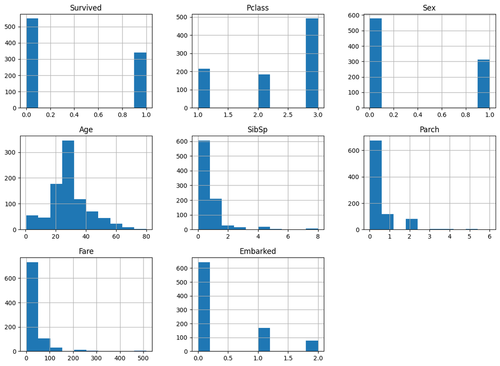

```python
cleaned.hist(figsize=(14, 10))
```

## پرسش 10:

```
array([[<AxesSubplot: title={'center': 'Pclass'}>,
        <AxesSubplot: title={'center': 'Sex'}>,
        <AxesSubplot: title={'center': 'Age'}>],
       [<AxesSubplot: title={'center': 'SibSp'}>,
        <AxesSubplot: title={'center': 'Parch'}>,
        <AxesSubplot: title={'center': 'Fare'}>],
       [<AxesSubplot: title={'center': 'Embarked'}>,
        <AxesSubplot: title={'center': 'Survived'}>, <AxesSubplot: >]],
      dtype=object)
```

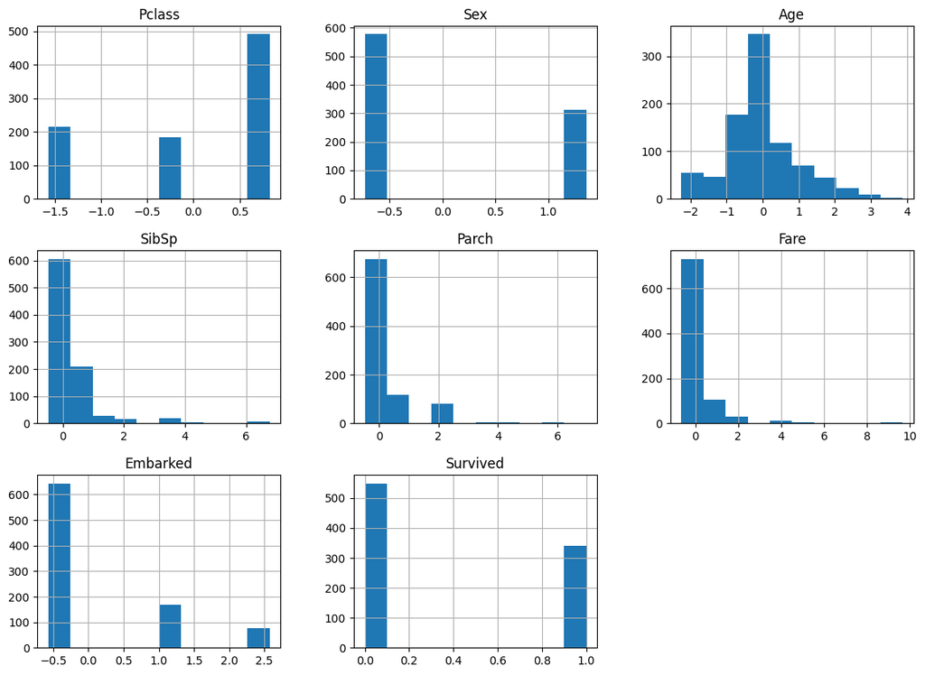

```python
# normalize numeric only columns except for survived
normalizedDf = cleaned.copy()
normalizedDf.drop('Survived', axis=1, inplace=True)
normalizedDf = (normalizedDf - normalizedDf.mean(numeric_only=True)) / normalizedDf.std(numeric_only=True)
normalizedDf['Survived'] = cleaned['Survived']
normalizedDf.hist(figsize=(14, 10))
```

```python
normalizedDf.describe()
```

|  | Pclass | Sex | Age | SibSp | Parch | Fare | Embarked | Survived |
| --- | --- | --- | --- | --- | --- | --- | --- | --- |
| count | 8.890000e+02 | 8.890000e+02 | 8.890000e+02 | 8.890000e+02 | 8.890000e+02 | 8.890000e+02 | 8.890000e+02 | 889.000000 |
| mean | -1.878263e-16 | -6.394085e-17 | 3.157080e-16 | -7.992607e-18 | -4.795564e-17 | 1.358743e-16 | -7.393161e-17 | 0.382452 |
| std | 1.000000e+00 | 1.000000e+00 | 1.000000e+00 | 1.000000e+00 | 1.000000e+00 | 1.000000e+00 | 1.000000e+00 | 0.486260 |
| min | -1.571327e+00 | -7.349283e-01 | -2.254212e+00 | -4.749317e-01 | -4.740590e-01 | -6.458409e-01 | -5.693635e-01 | 0.000000 |
| 25% | -3.732912e-01 | -7.349283e-01 | -5.901627e-01 | -4.749317e-01 | -4.740590e-01 | -4.869637e-01 | -5.693635e-01 | 0.000000 |
| 50% | 8.247444e-01 | -7.349283e-01 | 3.521745e-03 | -4.749317e-01 | -4.740590e-01 | -3.549973e-01 | -5.693635e-01 | 0.000000 |
| 75% | 8.247444e-01 | 1.359146e+00 | 4.122766e-01 | 4.311076e-01 | -4.740590e-01 | -2.206712e-02 | 1.002575e+00 | 1.000000 |
| max | 8.247444e-01 | 1.359146e+00 | 3.882259e+00 | 6.773383e+00 | 6.963090e+00 | 9.663111e+00 | 2.574513e+00 | 1.000000 |

همانطور که واضح است، انحراف معیار داده‌ها به 1 و میانگین آن‌ها به 0 میل کرده است.

## پرسش 11:

```python
def getMeanAndStd(df):
    return df.mean(numeric_only=True), df.std(numeric_only=True)

display(normalizedDf)
survivedDf = normalizedDf.loc[normalizedDf.Survived == 1].drop('Survived', axis=1)
survivedMean, survivedStd = getMeanAndStd(survivedDf)
notSurvivedDf = normalizedDf.loc[normalizedDf.Survived == 0].drop('Survived', axis=1)
notSurvivedMean, notSurvivedStd = getMeanAndStd(notSurvivedDf)

info = pd.DataFrame({
    'Survived Mean': survivedMean,
    'Not Survived Mean': notSurvivedMean,
    'Survived Std': survivedStd,
    'Not Survived Std': notSurvivedStd
})
display(info)
```

|  | Pclass | Sex | Age | SibSp | Parch | Fare | Embarked | Survived |
| --- | --- | --- | --- | --- | --- | --- | --- | --- |
| 0 | 0.824744 | -0.734928 | -0.590163 | 0.431108 | -0.474059 | -0.499958 | -0.569364 | 0 |
| 1 | -1.571327 | 1.359146 | 0.643609 | 0.431108 | -0.474059 | 0.788503 | 1.002575 | 1 |
| 2 | 0.824744 | 1.359146 | -0.281720 | -0.474932 | -0.474059 | -0.486376 | -0.569364 | 1 |
| 3 | -1.571327 | 1.359146 | 0.412277 | 0.431108 | -0.474059 | 0.422623 | -0.569364 | 1 |
| 4 | 0.824744 | -0.734928 | 0.412277 | -0.474932 | -0.474059 | -0.483861 | -0.569364 | 0 |
| ... | ... | ... | ... | ... | ... | ... | ... | ... |
| 884 | -0.373291 | -0.734928 | -0.204609 | -0.474932 | -0.474059 | -0.384258 | -0.569364 | 0 |
| 885 | -1.571327 | 1.359146 | -0.821495 | -0.474932 | -0.474059 | -0.042189 | -0.569364 | 1 |
| 886 | 0.824744 | 1.359146 | 0.003522 | 0.431108 | 2.004991 | -0.173986 | -0.569364 | 0 |
| 887 | -1.571327 | -0.734928 | -0.281720 | -0.474932 | -0.474059 | -0.042189 | 1.002575 | 1 |
| 888 | 0.824744 | -0.734928 | 0.180944 | -0.474932 | -0.474059 | -0.489897 | 2.574513 | 0 |

889 rows × 8 columns

|  | Survived Mean | Not Survived Mean | Survived Std | Not Survived Std |
| --- | --- | --- | --- | --- |
| Pclass | -0.426146 | 0.263915 | 1.033621 | 0.881521 |
| Sex | 0.687811 | -0.425967 | 0.978751 | 0.743329 |
| Age | -0.094834 | 0.058732 | 1.055095 | 0.960597 |
| SibSp | -0.043231 | 0.026773 | 0.643141 | 1.167340 |
| Parch | 0.105601 | -0.065400 | 0.958346 | 1.020335 |
| Fare | 0.324218 | -0.200791 | 1.343101 | 0.631585 |
| Embarked | 0.138009 | -0.085470 | 1.025045 | 0.975354 |

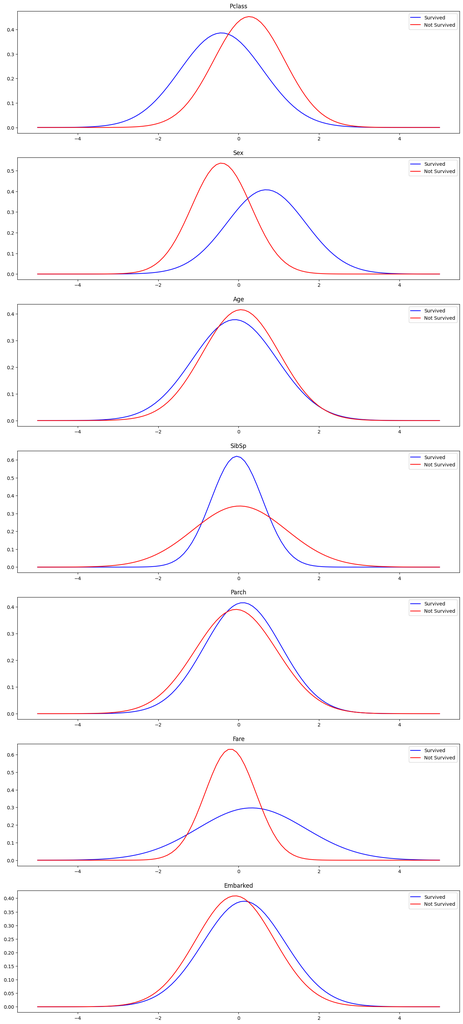

```python
x = np.linspace(-5, 5, 100)
fig, axes = plt.subplots(nrows=info.shape[0], ncols=1, figsize=(14, 30))
fig.tight_layout(pad=3.0)

def plotNormal(idx, mean, std, label, color):
    y = sp.stats.norm.pdf(x, mean, std)
    axes[idx].plot(x, y, label=label, color=color)
    axes[idx].legend()

def plot(idx, name, row):
    plotNormal(idx, row['Survived Mean'], row['Survived Std'], 'Survived', 'blue')
    plotNormal(idx, row['Not Survived Mean'], row['Not Survived Std'], 'Not Survived', 'red')
    axes[idx].set_title(name)

for idx, (name, row) in enumerate(info.iterrows()):
    plot(idx, name, row)
```

برای پیش‌بینی زنده ماندن یا زنده نماندن افراد بهتر است از ویژگی‌هایی استفاده کنیم که تفاوت زیادی در مقادیر آن‌ها بین افرادی که زنده مانده‌اند و افرادی که زنده نمانده‌اند وجود داشته باشد. در واقع ویژگی‌ای مد نظر است که دو نمودار آن اختلاف زیادی با هم داشته باشند.  
همانطور که در نمودارها واضح است، بهترین ویژگی برای پیش‌بینی زنده ماندن یا نماندن افراد، **جنسیت** است. در قطعه کد زیر ویژگی‌های مختلف را با هم مقایسه می‌کنیم که از انتخاب خود مطمئن شویم.

```python
def getCollisionPoints(mean1, std1, mean2, std2):
    a = 1 / (2 * std1**2) - 1 / (2 * std2**2)
    b = mean2 / (std2**2) - mean1 / (std1**2)
    c = mean1**2 / (2 * std1**2) - mean2**2 / (2 * std2**2) - np.log(std2 / std1)
    res = np.roots([a, b, c])
    res.sort()
    return res
```

```python
def willSurvive(normalizedX, collisionPoints, survivedInMiddle):
    if survivedInMiddle:
        return 1 if collisionPoints[0] < normalizedX < collisionPoints[1] else 0
    else:
        return 1 if normalizedX < collisionPoints[0] or normalizedX > collisionPoints[1] else 0
```

در بخش زیر، دیکشنری survivedInMiddle بیانگر این است که بین نقاط تلاقی دو نمودار ویژگی مدنظر، کدام نمودار بالاتر از دیگری قرار می‌گیرد.

```python
survivedInMiddle = {
    'Pclass': 0,
    'Sex': 0,
    'Age': 0,
    'SibSp': 1,
    'Parch': 1,
    'Fare': 0,
    'Embarked': 0
}

df = pd.DataFrame()
collisionPoints = {}
for idx, (name, row) in enumerate(info.iterrows()):
    collisionPoints[str(name)] = getCollisionPoints(row['Survived Mean'], row['Survived Std'], row['Not Survived Mean'], row['Not Survived Std'])
    df[name] = normalizedDf[str(name)].apply(lambda x: willSurvive(x, collisionPoints[str(name)], survivedInMiddle[str(name)]))
    correct = df.loc[df[str(name)] == cleaned['Survived']].shape[0]
    print(f"{name:8} -> Correct Predictions: {correct} | Accuracy: {correct / df.shape[0] * 100:.2f}%")
```

```
Pclass   -> Correct Predictions: 593 | Accuracy: 66.70%
Sex      -> Correct Predictions: 699 | Accuracy: 78.63%
Age      -> Correct Predictions: 493 | Accuracy: 55.46%
SibSp    -> Correct Predictions: 374 | Accuracy: 42.07%
Parch    -> Correct Predictions: 561 | Accuracy: 63.10%
Fare     -> Correct Predictions: 589 | Accuracy: 66.25%
Embarked -> Correct Predictions: 550 | Accuracy: 61.87%
```

همانطور که نتایج نشان می‌دهد، دقت پیش‌بینی با استفاده از ویژگی جنسیت بالاتر از دیگر ویژگی‌ها است.

## پرسش 12:

```python
test = pd.read_csv('test.csv')
display(test.info())
```

```
<class 'pandas.core.frame.DataFrame'>
RangeIndex: 418 entries, 0 to 417
Data columns (total 11 columns):
 #   Column       Non-Null Count  Dtype
---  ------       --------------  -----
 0   PassengerId  418 non-null    int64
 1   Pclass       418 non-null    int64
 2   Name         418 non-null    object
 3   Sex          418 non-null    object
 4   Age          332 non-null    float64
 5   SibSp        418 non-null    int64
 6   Parch        418 non-null    int64
 7   Ticket       418 non-null    object
 8   Fare         417 non-null    float64
 9   Cabin        91 non-null     object
 10  Embarked     418 non-null    object
dtypes: float64(2), int64(4), object(5)
memory usage: 36.0+ KB
```

```
None
```

```python
cleanedTest = test.copy()
cleanedTest.drop('PassengerId', axis=1, inplace=True)
cleanedTest.drop('Pclass', axis=1, inplace=True)
cleanedTest.drop('Name', axis=1, inplace=True)
cleanedTest.drop('Age', axis=1, inplace=True)
cleanedTest.drop('SibSp', axis=1, inplace=True)
cleanedTest.drop('Parch', axis=1, inplace=True)
cleanedTest.drop('Ticket', axis=1, inplace=True)
cleanedTest.drop('Fare', axis=1, inplace=True)
cleanedTest.drop('Cabin', axis=1, inplace=True)
cleanedTest.drop('Embarked', axis=1, inplace=True)
cleanedTest['Sex'].replace(sex, inplace=True)
display(cleanedTest)
```

|  | Sex |
| --- | --- |
| 0 | 0 |
| 1 | 1 |
| 2 | 0 |
| 3 | 0 |
| 4 | 1 |
| ... | ... |
| 413 | 0 |
| 414 | 1 |
| 415 | 0 |
| 416 | 0 |
| 417 | 0 |

418 rows × 1 columns

```python
mean, std = getMeanAndStd(cleaned['Sex'])
normalizedTest = (cleanedTest['Sex'] - mean) / std
result = pd.DataFrame()
result['Survived'] = normalizedTest.apply(lambda x: willSurvive(x, collisionPoints['Sex'], 0))
display(result)
```

|  | Survived |
| --- | --- |
| 0 | 0 |
| 1 | 1 |
| 2 | 0 |
| 3 | 0 |
| 4 | 1 |
| ... | ... |
| 413 | 0 |
| 414 | 1 |
| 415 | 0 |
| 416 | 0 |
| 417 | 0 |

418 rows × 1 columns

```python
result.to_csv('result.csv')
```